# Practical Lab 4

## Student Name: `Simardeep Singh`

## Student Roll Number:`8976948`

**Dear Product Manager** In this lab we are exploring multivariate regression using polynomial, decision trees, and kNN to optimize a model for predicting diabetes disease progression.

#### IMPORTING LIBRARIES

```python
import numpy as np
import matplotlib.pyplot as plt
from sklearn.datasets import load_diabetes
import pandas as pd
import seaborn as sns
import matplotlib.pyplot as plt
from sklearn.preprocessing import StandardScaler
from sklearn.model_selection import train_test_split
from sklearn.preprocessing import PolynomialFeatures
from sklearn.tree import DecisionTreeRegressor
from sklearn.neighbors import KNeighborsRegressor
from sklearn.model_selection import cross_validate
from sklearn.preprocessing import PolynomialFeatures
from sklearn.linear_model import LinearRegression
from sklearn.metrics import make_scorer, mean_absolute_error, mean_squared_error, r2_score
```

#### Q1) Utilize the diabetes dataset (same as of lab 4)

```python
diabetes_data = load_diabetes()
diabetes_df = pd.DataFrame(data=np.c_[diabetes_data['data'], diabetes_data['target']], columns=np.append(diabetes_data['feature_names'], 'target'))
print(diabetes_df.info())
```

```
<class 'pandas.core.frame.DataFrame'>
RangeIndex: 442 entries, 0 to 441
Data columns (total 11 columns):
 #   Column  Non-Null Count  Dtype
---  ------  --------------  -----
 0   age     442 non-null    float64
 1   sex     442 non-null    float64
 2   bmi     442 non-null    float64
 3   bp      442 non-null    float64
 4   s1      442 non-null    float64
 5   s2      442 non-null    float64
 6   s3      442 non-null    float64
 7   s4      442 non-null    float64
 8   s5      442 non-null    float64
 9   s6      442 non-null    float64
 10  target  442 non-null    float64
dtypes: float64(11)
memory usage: 38.1 KB
None
```

#### Q2) EDA exploration

- Result Shows Skewed Distribution
- Count result of feature 'Sex' shows are small difference of approx. 25
- corelation btw age and target value shows non linear Relationship
- In box plot , it shows that the median value for feature 'Sex' is exactly at the edge of the box.
- There are no missing values in the dataset.

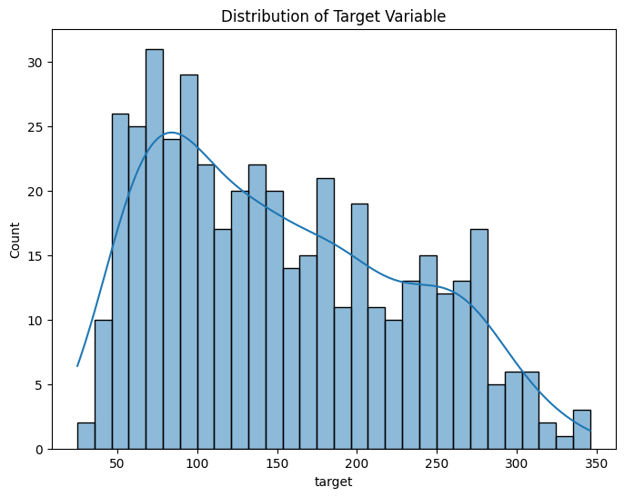

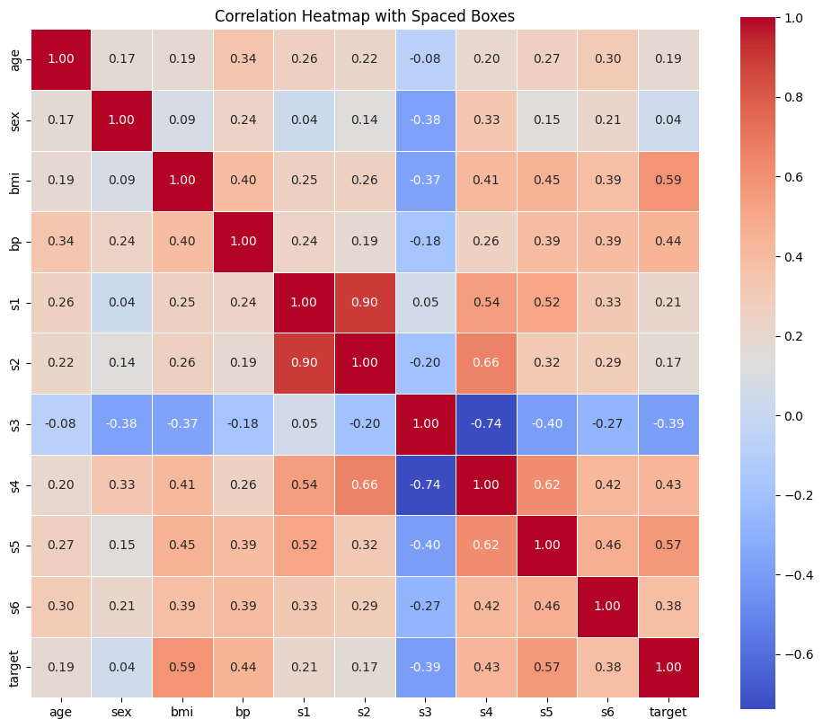

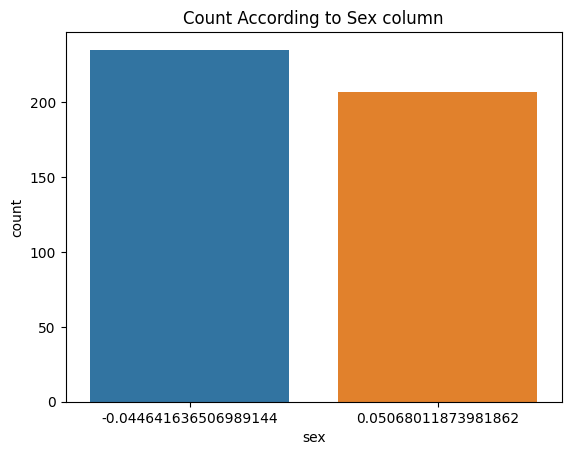

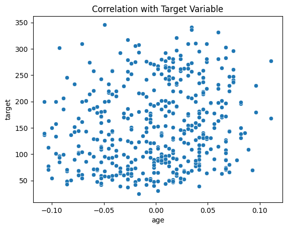

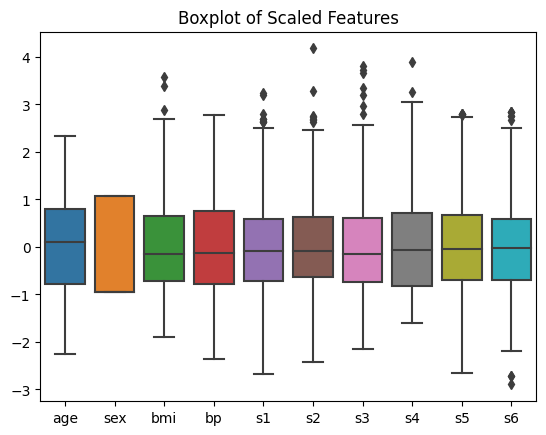

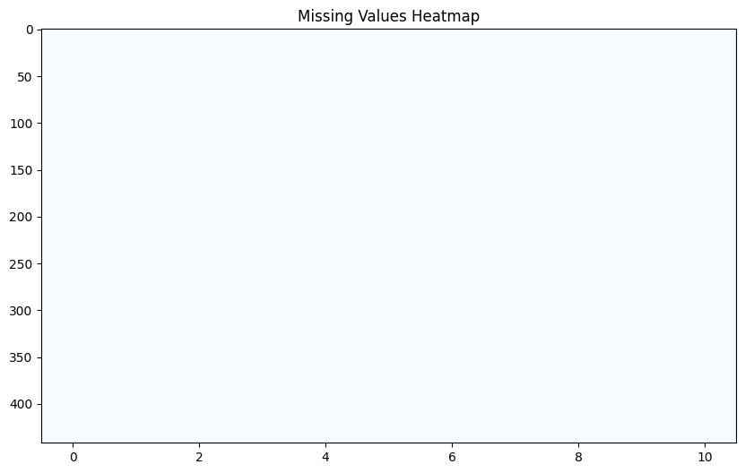

```python
#Distribution of Target Variable
plt.figure(figsize=(8, 6))
sns.histplot(diabetes_df['target'], bins=30, kde=True)
plt.title('Distribution of Target Variable')
plt.show()

# Correlation heatmap
correlation_matrix = diabetes_df.corr()
plt.figure(figsize=(12, 10))
sns.heatmap(correlation_matrix, annot=True, cmap='coolwarm', fmt=".2f", linewidths=.5, square=True)
plt.title('Correlation Heatmap with Spaced Boxes')
plt.show()

# Count According to Sex column
sns.countplot(x='sex', data=diabetes_df)
plt.title('Count According to Sex column')
plt.show()

#  correlation Age with the target variable
sns.scatterplot(x='age', y='target', data=diabetes_df)
plt.title('Correlation with Target Variable')
plt.show()

#Feature Scaling
scaler = StandardScaler()
diabetes_scaled = scaler.fit_transform(diabetes_df.drop('target', axis=1))
sns.boxplot(data=pd.DataFrame(diabetes_scaled, columns=diabetes_df.columns[:-1]))
plt.title('Boxplot of Scaled Features')
plt.show()

# ploting missing values
missing_values_matrix = diabetes_df.isnull()
plt.figure(figsize=(10, 6))
plt.imshow(missing_values_matrix, cmap='Blues', aspect='auto',interpolation='none')
plt.title('Missing Values Heatmap')
plt.show()
```

#### Q3) Going forward, you can use all features in the dataset, or drop some features per your discretion based on the EDA.

** Based on Heat map above we are removing features whose correlation value is <0.2 **

```python
diabetes_df_filtered = diabetes_df.drop(columns=['sex', 's2', 'age'])
print(diabetes_df_filtered.head())
```

```
        bmi        bp        s1        s3        s4        s5        s6
0  0.061696  0.021872 -0.044223 -0.043401 -0.002592  0.019907 -0.017646  \
1 -0.051474 -0.026328 -0.008449  0.074412 -0.039493 -0.068332 -0.092204
2  0.044451 -0.005670 -0.045599 -0.032356 -0.002592  0.002861 -0.025930
3 -0.011595 -0.036656  0.012191 -0.036038  0.034309  0.022688 -0.009362
4 -0.036385  0.021872  0.003935  0.008142 -0.002592 -0.031988 -0.046641

   target
0   151.0
1    75.0
2   141.0
3   206.0
4   135.0
```

#### Q4) Set a test-set aside.

```python
X = diabetes_df_filtered.drop('target', axis=1)
y = diabetes_df_filtered['target']

X_train, X_test, y_train, y_test = train_test_split(X, y, test_size=0.2, random_state=42)
print("Shape of Training:", X_train.shape, y_train.shape)
print("Shape of Test set:", X_test.shape, y_test.shape)
```

```
Shape of Training: (353, 7) (353,)
Shape of Test set: (89, 7) (89,)
```

#### Q5) Perform cross-validation. consider using the cross_validate function as it provides a list of scoring functions as an input (1 point). This should be on:

```python
results_list = []
selected_degrees = [2, 3]

selected_degrees = [2, 3]
for degree in selected_degrees:
    poly_features = PolynomialFeatures(degree=degree)
    X_poly = poly_features.fit_transform(X_train)

    poly_model = LinearRegression()

    scoring = {'r2': 'r2', 'mae': 'neg_mean_absolute_error', 'mape': make_scorer(lambda y_true, y_pred: mean_absolute_error(y_true, y_pred) / np.mean(np.abs(y_true)) * 100)}

    results = cross_validate(poly_model, X_poly, y_train, cv=5, scoring=scoring, return_train_score=False)

    results_list.append({
        'Model': f'Polynomial Regression (Degree {degree})',
        'Mean R-Squared': np.mean(results['test_r2']),
        'Std R-Squared': np.std(results['test_r2']),
        'Mean MAE': -np.mean(results['test_mae']),
        'Std MAE': np.std(results['test_mae']),
        'Mean MAPE': -np.mean(results['test_mape']),
        'Std MAPE': np.std(results['test_mape']),


    })
```

##### 2) At least two decision trees (e.g. consider changing the `max_depth` hyperparameter)

```python
depth_values = [7, 10]
for max_depth in depth_values:
    decision_tree_model = DecisionTreeRegressor(max_depth=max_depth, random_state=42)

    scores = cross_validate(decision_tree_model, X_train, y_train, cv=5,
                            scoring={'r2': 'r2', 'mae': 'neg_mean_absolute_error', 'mape': make_scorer(lambda y_true, y_pred: mean_absolute_error(y_true, y_pred) / np.mean(np.abs(y_true)) * 100)},
                            return_train_score=False)

    results_list.append({
        'Model': f'Decision Tree (Max Depth {max_depth})',
        'Mean R-Squared': np.mean(scores['test_r2']),
        'Std R-Squared': np.std(scores['test_r2']),
        'Mean MAE': -np.mean(scores['test_mae']),
        'Std MAE': np.std(scores['test_mae']),
        'Mean MAPE': -np.mean(scores['test_mape']),
        'Std MAPE': np.std(scores['test_mape'])
    })
```

##### 3) At least two kNNs

```python
k_values = [5, 7]
for k_neighbors in k_values:
    knn_model = KNeighborsRegressor(n_neighbors=k_neighbors)

    scores = cross_validate(knn_model, X_train, y_train, cv=5,
                            scoring={'r2': 'r2', 'mae': 'neg_mean_absolute_error', 'mape': make_scorer(lambda y_true, y_pred: mean_absolute_error(y_true, y_pred) / np.mean(np.abs(y_true)) * 100)},
                            return_train_score=False)

    results_list.append({
        'Model': f'k-Nearest Neighbors (k={k_neighbors})',
        'Mean R-Squared': np.mean(scores['test_r2']),
        'Std R-Squared': np.std(scores['test_r2']),
        'Mean MAE': -np.mean(scores['test_mae']),
        'Std MAE': np.std(scores['test_mae']),
        'Mean MAPE': -np.mean(scores['test_mape']),
        'Std MAPE': np.std(scores['test_mape'])
    })
```